# RepData_PeerAssessment

Alvaro Fierro

15 de octubre de 2015

## Loading and preprocessing the data

```r
setwd("C:/Users/Usuario/Google Drive/R programming/5. Reproducible Research/")
activity<-read.csv("activity.csv")
days<-levels(factor(activity$date))
library(doBy)
steps_per_date<-summaryBy(steps~date, data=activity, FUN=sum)
#average_steps_per_date<-summaryBy(steps~date, data=activity, FUN=mean)
```

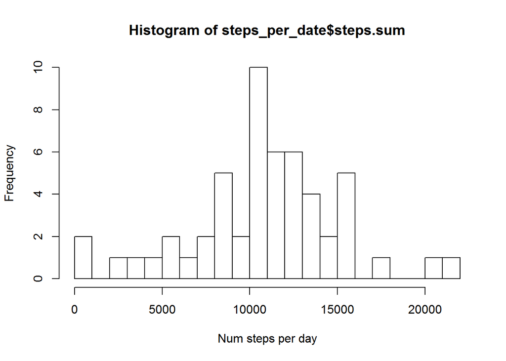

## What is mean total number of steps taken per day?

The mean of the number of steps per day is 10766 and the median is 10765.

# What is the average daily activity pattern?

```r
# Create a matrix (61 days x 288 periods of 5 minutes) that contains
# by column, the activity each 5-minutes period of time for the 61 days
five_minutes_steps_average<-matrix(activity$steps,byrow=TRUE,ncol =288)

# Compute the average per column: a vector with 288 positions, 1 per
# 5-minutes interval of the day, that corresponds to the mean of the 61 days
library(Matrix)
five_minutes_steps_average_per_day<-colMeans(five_minutes_steps_average, na.rm=TRUE)
```

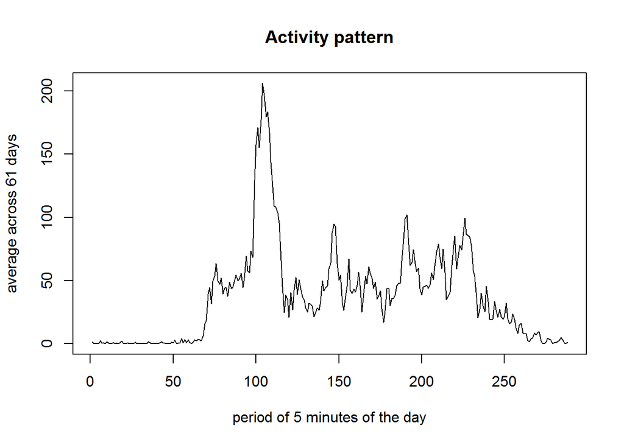

```r
max_steps <- which(five_minutes_steps_average_per_day==max(five_minutes_steps_average_per_day))
step_hour <- round(max_steps/12)
```

The 5-minute interval, on average across all the days in the dataset, that contains the maximum number of steps is 104 that corresponds to the 9 th hour of the day.

## Imputing missing values

```r
# Calculate missing values

# Total number
num_na <- sum(is.na(activity$steps))

# Number of missing values per day
library(matrixStats)
col_na <- apply(five_minutes_steps_average,2,is.na)
colCounts(col_na)
```

```
##   [1] 8 8 8 8 8 8 8 8 8 8 8 8 8 8 8 8 8 8 8 8 8 8 8 8 8 8 8 8 8 8 8 8 8 8 8
##  [36] 8 8 8 8 8 8 8 8 8 8 8 8 8 8 8 8 8 8 8 8 8 8 8 8 8 8 8 8 8 8 8 8 8 8 8
##  [71] 8 8 8 8 8 8 8 8 8 8 8 8 8 8 8 8 8 8 8 8 8 8 8 8 8 8 8 8 8 8 8 8 8 8 8
## [106] 8 8 8 8 8 8 8 8 8 8 8 8 8 8 8 8 8 8 8 8 8 8 8 8 8 8 8 8 8 8 8 8 8 8 8
## [141] 8 8 8 8 8 8 8 8 8 8 8 8 8 8 8 8 8 8 8 8 8 8 8 8 8 8 8 8 8 8 8 8 8 8 8
## [176] 8 8 8 8 8 8 8 8 8 8 8 8 8 8 8 8 8 8 8 8 8 8 8 8 8 8 8 8 8 8 8 8 8 8 8
## [211] 8 8 8 8 8 8 8 8 8 8 8 8 8 8 8 8 8 8 8 8 8 8 8 8 8 8 8 8 8 8 8 8 8 8 8
## [246] 8 8 8 8 8 8 8 8 8 8 8 8 8 8 8 8 8 8 8 8 8 8 8 8 8 8 8 8 8 8 8 8 8 8 8
## [281] 8 8 8 8 8 8 8 8
```

```r
# We see that the missing values are located at the same 5-minutes moments every day!
# There are 8 missing values every day

# Replace missing values with average per 5-minutes chunk of time. This value is
# contained in the vector «five_minutes_steps_average_per_day».

for (col in 1: dim(five_minutes_steps_average)[2]) { # perform on every column
        # replace null values with corresponding 5-minutes chunk average
  five_minutes_steps_average[which(is.na(five_minutes_steps_average[,col])),col] <-five_minutes_steps_average_per_day[col]
}

# In order to calculate total number of steps per day, we perform  the sum of
# five_minutes_steps_average per rows
steps_per_day<-apply(five_minutes_steps_average,1,sum)

# Perform mean and median
steps_per_day_mean<-format(round(mean(steps_per_day)), scientific=FALSE)
steps_per_day_median<-format(round(median(steps_per_day)), scientific=FALSE)
```

The total number of missing values in the dataset is 2304. The strategy we are going to follow in order to fill in those NA values is to choose the average for all days of the 5-minute available values that correspond to that chunk of time.

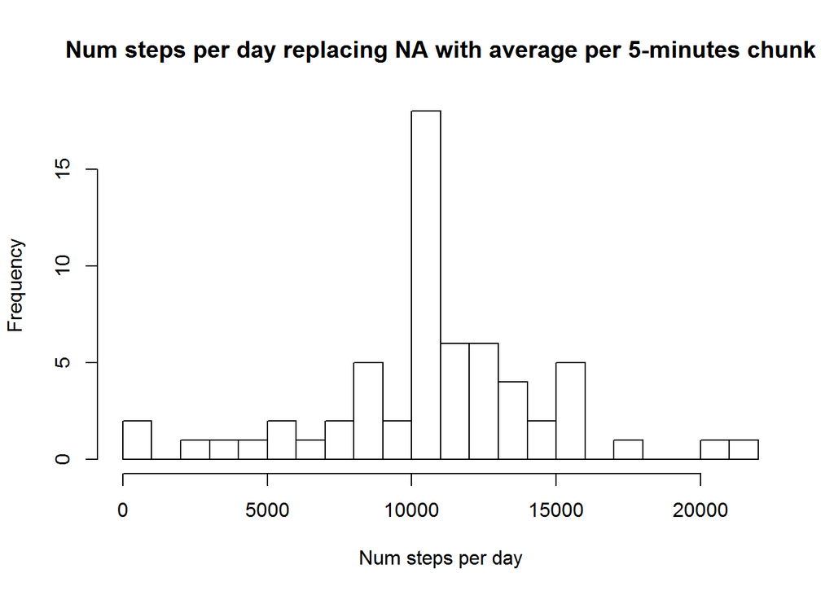

The mean of this dataset with no NA values is 10766 and the median is 10766. These two values are the same that those of the dataset with NA values because the unavailable values have been replaced by means, thus not altering these two measures. Nevertheless, the histogram shows higher accounts due to the fact that 2304 values that were not present in the initial graph have been now included.

## Are there differences in activity patterns between weekdays and weekends?

```r
# Grab day of the week
activity$day_week<-weekdays(as.Date(activity$date))

# Factor weekday / weekend
activity$day_type<-lapply(activity$day_week, function(x) if(x=="sábado" ||x=="domingo") "weekend" else "weekday")

# Subset weekday/weekend
weekday_activity<-activity[which(activity$day_type=="weekday"),]
weekend_activity<-activity[which(activity$day_type=="weekend"),]
```

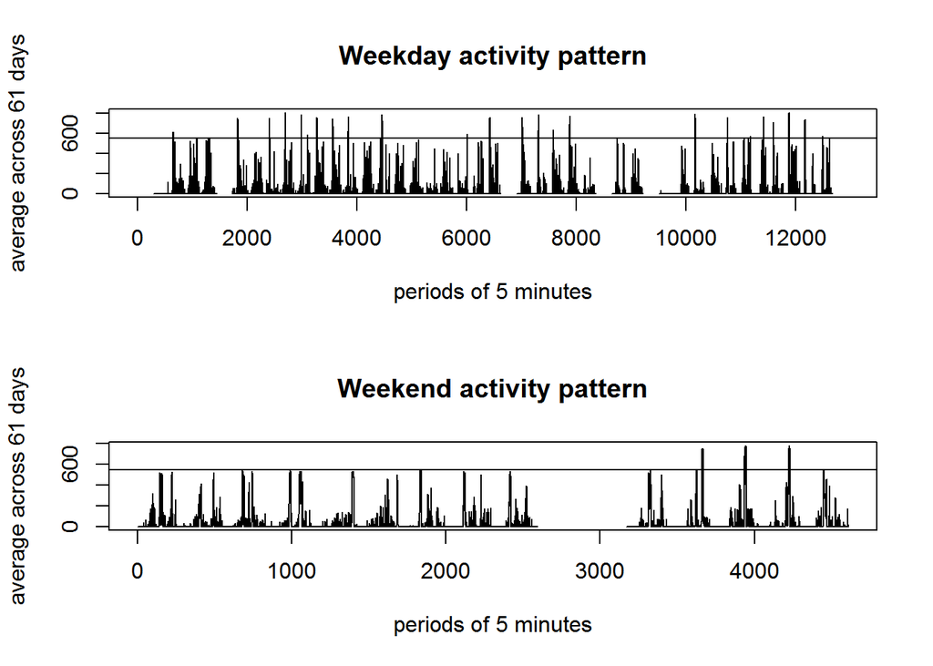

The plots show different activity patterns between weekdays and weekends. During saturdays and sundays, peak activity only goes beyond a value of 550 in three occasions at the end of the considered period of time, whereas this threshold is exceeded usually during weekdays.